# Part II - Ford GoBike System Dataset Analysis

## by Abderrahmen Mansour

## Investigation Overview

In this analysis, I focused on several variables that can affect the frequency of trips: Day of week and hour of day, and how the duration of each trip can vary by user types, day of week, and hour of day. In addition, I analyzed User types by distance /duration of trip, and age of user.

## Dataset Overview

The dataset contains ride data information for about 183,000 rides in the Ford GoBike system covering the greater San Francisco Bay area, with variables including user behavior (duration, date-time, station location) and demographic information (user type, gender, age).

## Trip distribution by day of the week and hour

**On what day of the week is there the most traffic?**

**During which time of day is there the most traffic?**

> - The highest traffic volume occurs between 7 and 9 a.m. and between 4 and 6 p.m.
> - Between 10 a.m. and 3 p.m., the hourly traffic volume is about 7,500.
> - Before 7 a.m. and after 6 p.m., the number of trips decreases sharply.
> - During the midnight hours (1-5 a.m.), only a few people ride GoBike.

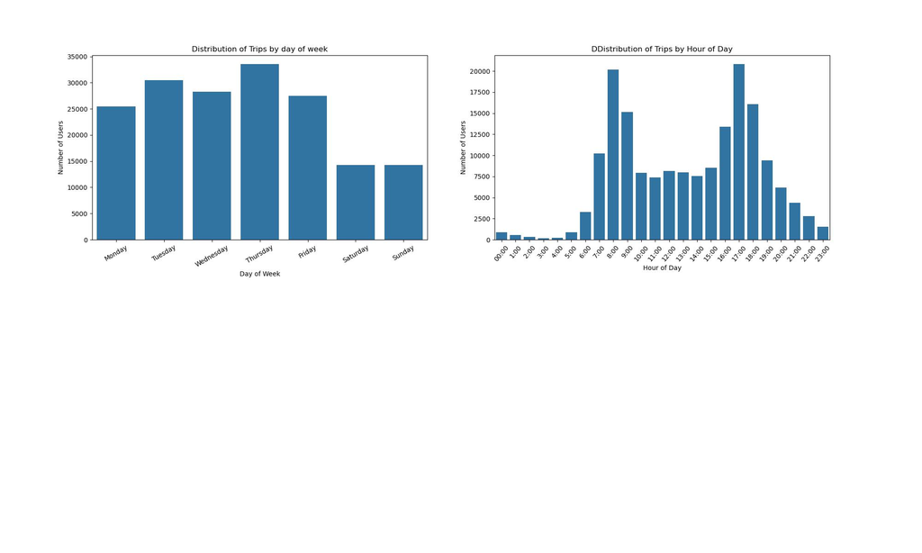

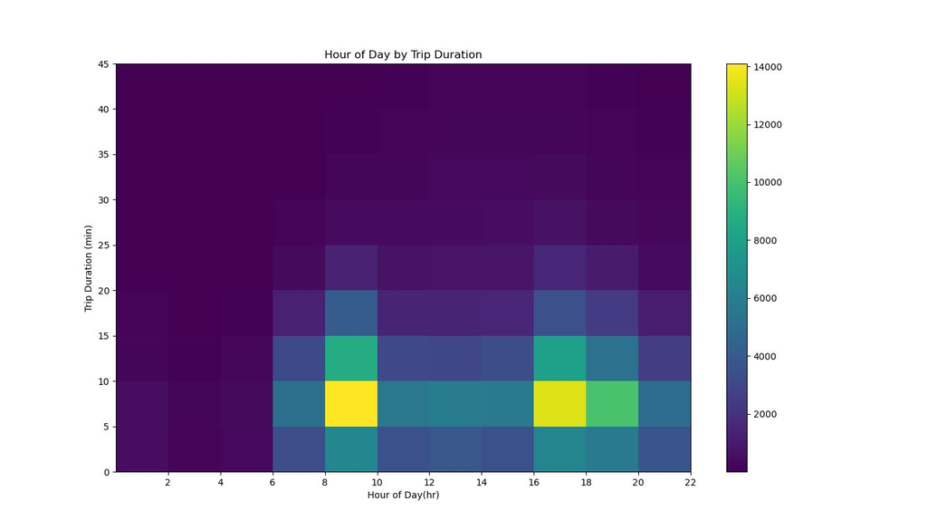

## Durations by day of the week per user type

**What is the usage behavior of the different user types?**

> - Subscriber usage time during the week does not change much on average.
> - On weekends, the duration of customers are higher than on weekdays.
> - On average, the duration of customers is higher than that of daily subscribers.

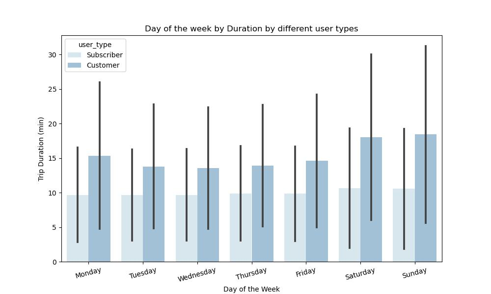

## Number of customers vs. Number of subscribers

> There are 9 times more subscribers than customers in the dataset.

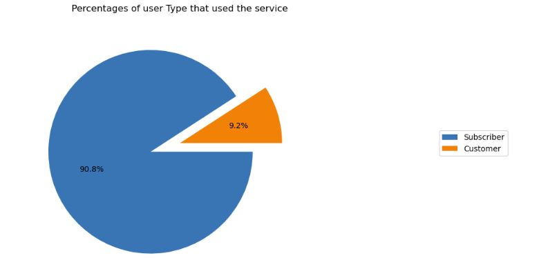

## Distance Cycled vs. type of Customer

> Subscribers tend to make short trips, while customers tend to make long trips.

Note: Outliers have been removed from this chart.

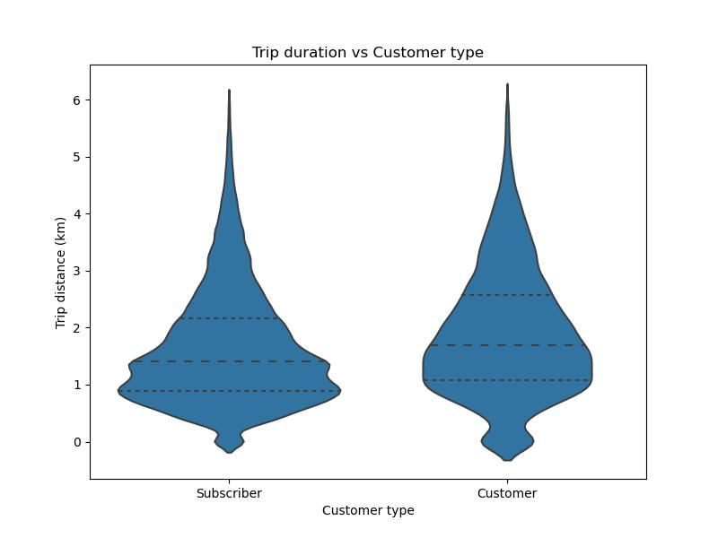

## Age vs. customer type

There is no significant correlation between age and customer type.

Note: Age axis ends at 80 years.

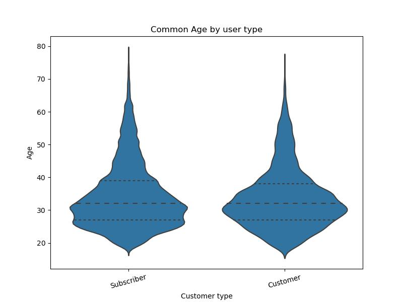

## Trip duration vs. Customer type

Subscribers tend to travel for shorter durations, while customers tend to travel for longer durations.

[figure not shown]

## Age vs Trip Duration/Distance by different Customer types

> - Subscribers are more likely to travel between 500 and 1500 m for 4 to 8 minutes and are between 25 and 35 years old
> - Customers are more likely to travel between 1000 and 2000 m for 4 to 16 minutes and are between 25 and 35 years old

Note:

- Outliers have been removed from this chart.
- the age axis ends at 80 years.

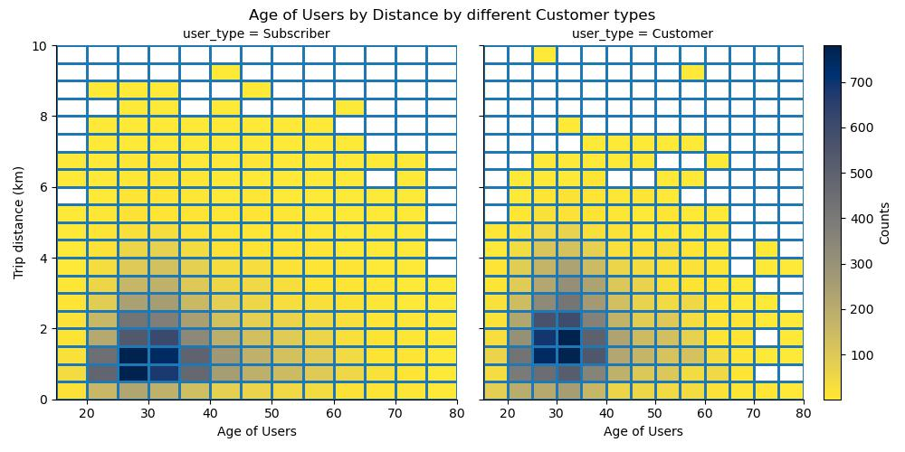

# Summary